# The issue with pie chart

# And often made even worse

Even if pie charts are bad by definition, it is still possible to make them even worse by adding other bad features:

- 3d
- legend aside
- percentages that do not sum to 100
- too many items
- exploded pie charts

# Alternatives

The [barplot](https://www.data-to-viz.com/graph/barplot.html) is the best alternative to pie plots. If you have many values to display, you can also consider a [lollipop](https://www.data-to-viz.com/graph/lollipop.html) plot that is a bit more elegant in my opinion. Here is an example based on the [amount of weapons sold](http://www.data-to-viz.com/story/OneNumOneCat.html) by a few countries in the world:

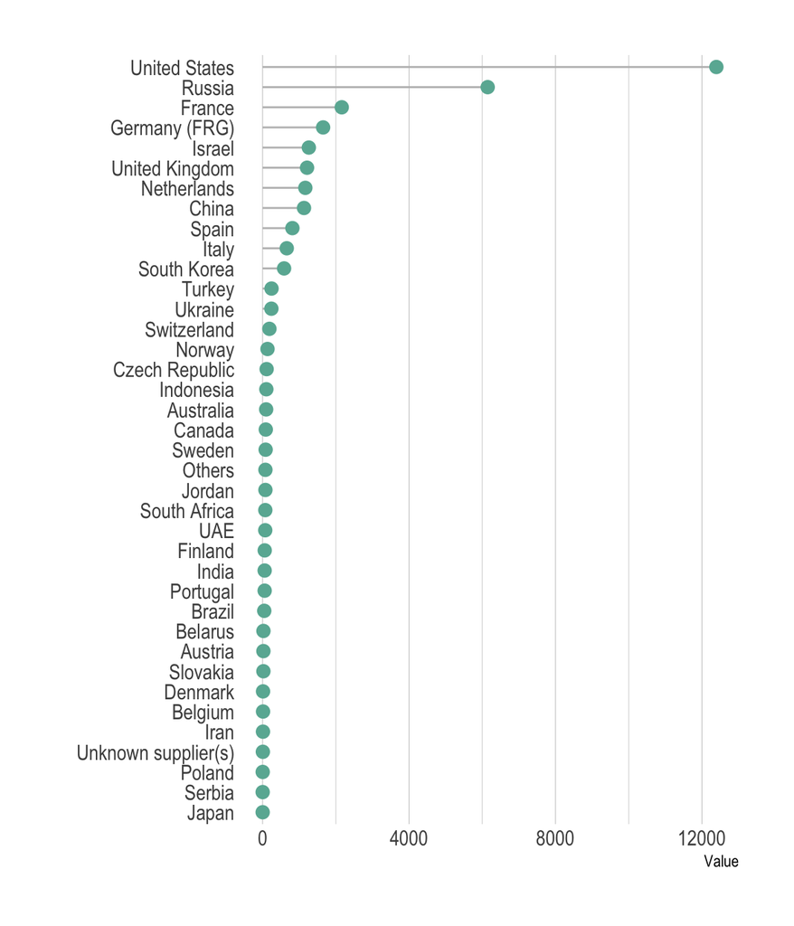

```r
# Load dataset from github
data <- read.table("https://raw.githubusercontent.com/holtzy/data_to_viz/master/Example_dataset/7_OneCatOneNum.csv", header=TRUE, sep=",")

# plot
data %>%
  filter(!is.na(Value)) %>%
  arrange(Value) %>%
  mutate(Country=factor(Country, Country)) %>%
  ggplot( aes(x=Country, y=Value) ) +
    geom_segment( aes(x=Country ,xend=Country, y=0, yend=Value), color="grey") +
    geom_point(size=3, color="#69b3a2") +
    coord_flip() +
    theme_ipsum() +
    theme(
      panel.grid.minor.y = element_blank(),
      panel.grid.major.y = element_blank(),
      legend.position="none"
    ) +
    xlab("")
```

Another possibility would be to create a treemap if your goal is to describe what the whole is composed of.

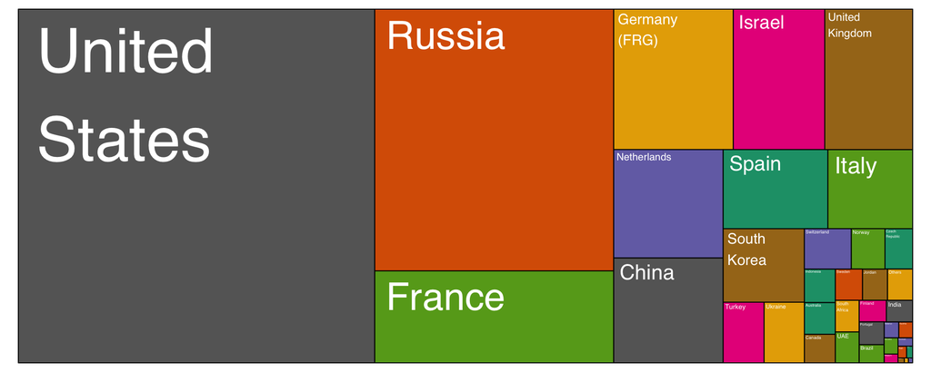

```r
# Package
library(treemap)

# Plot
treemap(data,

            # data
            index="Country",
            vSize="Value",
            type="index",

            # Main
            title="",
            palette="Dark2",

            # Borders:
            border.col=c("black"),
            border.lwds=1,

            # Labels
            fontsize.labels=0.5,
            fontcolor.labels="white",
            fontface.labels=1,
            bg.labels=c("transparent"),
            align.labels=c("left", "top"),
            overlap.labels=0.5,
            inflate.labels=T                        # If true, labels are bigger when rectangle is bigger.


            )
```

# Going further

- [Who sells more weapons](http://www.data-to-viz.com/story/OneNumOneCat.html): see this story that gives several alternatives to pie plot.
- Four problems with Pie Charts (And what to do instead) by [iCharts.net](https://icharts.net/blog/data-visualization-guides/4-problems-pie-charts-instead)
- The worst chart in the world by [Business insider](https://www.businessinsider.com.au/pie-charts-are-the-worst-2013-6?r=US&IR=T)
- doing pie plots in [R](https://www.r-graph-gallery.com/pie-plot/) and [Python](https://python-graph-gallery.com/pie-plot/)

# Comments

Any thoughts on this? Found any mistake? Disagree? Please drop me a word on [twitter](https://twitter.com/R_Graph_Gallery) or in the comment section below:

A work by [Yan Holtz](https://github.com/holtzy/) for data-to-viz.com